# Results

## Religious?

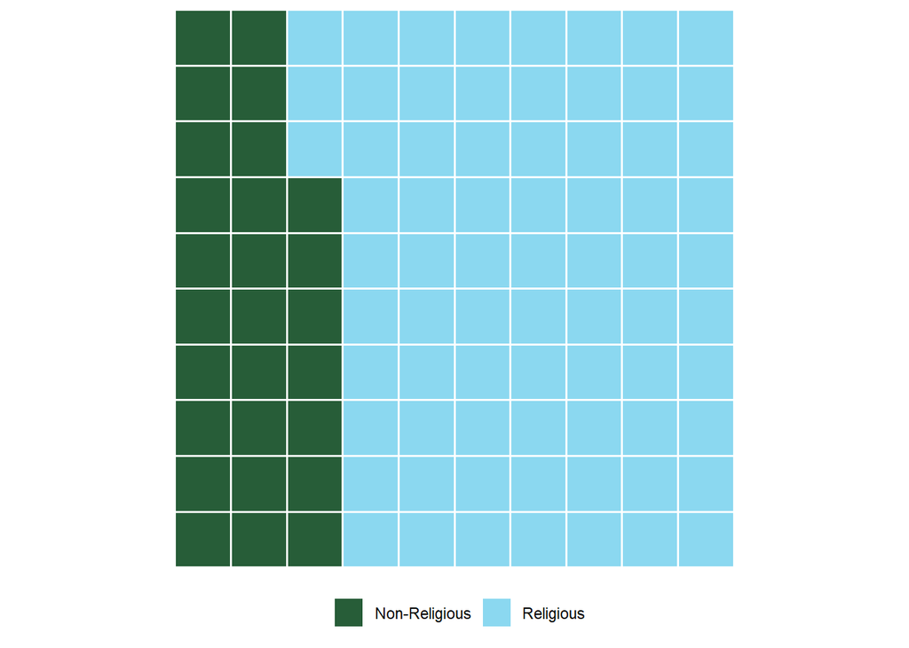

The data indicates the distribution of respondents based on their religious affiliations. Among those surveyed, approximately 27% identified as Non-Religious, while around 73% identified as Religious.

## First Generation Student?

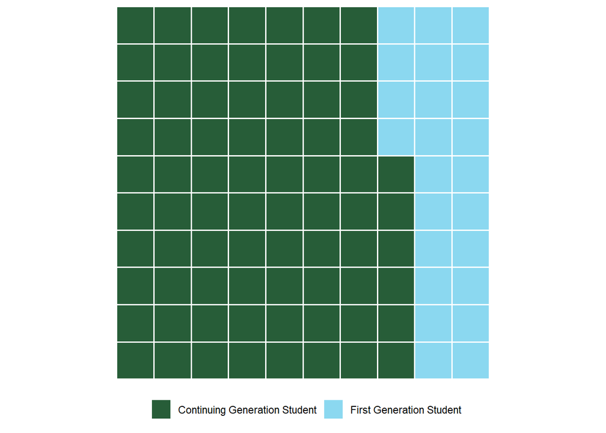

The data represents the distribution of students based on their generational status. Among those surveyed, approximately 76% identified as Continuing Generation Students (at least one parent attended college), while around 24% identified as First Generation Students (no parents attended college).

## Medical Experience?

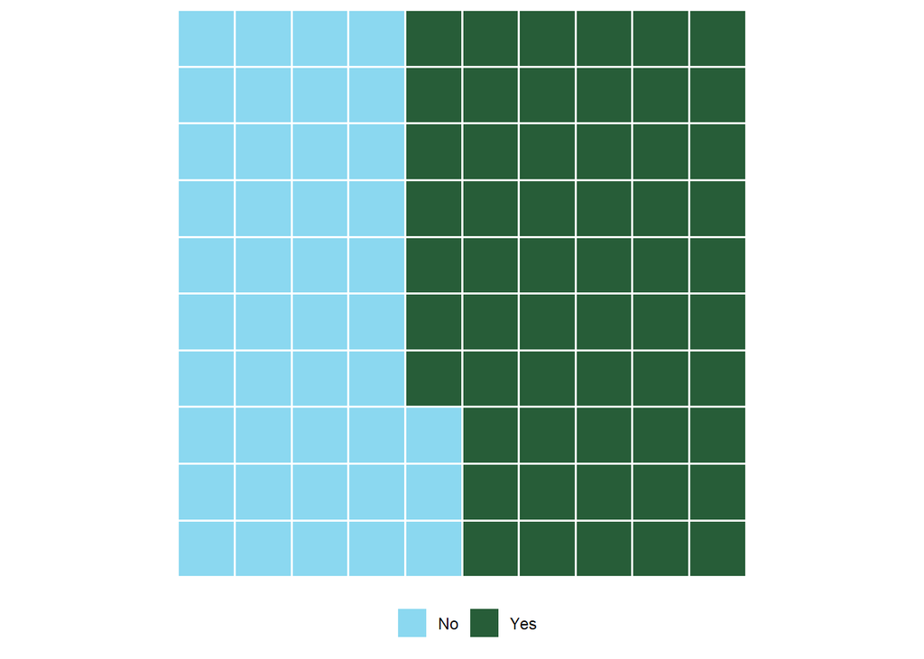

The data illustrates the percentage of those who identified to have had a medical experience. Among those surveyed, approximately 44% answered “No” while around 56% answered “Yes”.

## Chronic Condition?

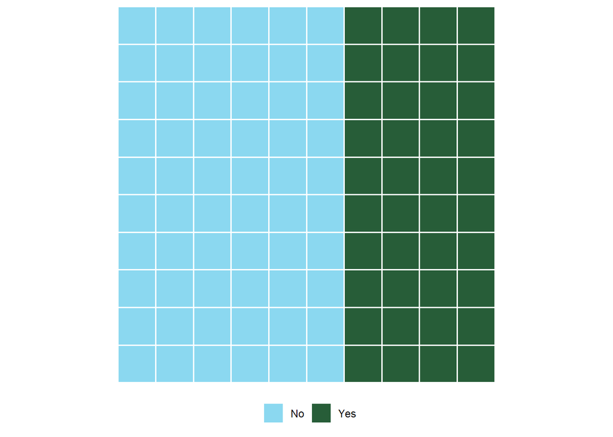

Of those who identified as had a medical experience, approximately 60% answered “No” while around 40% answered “Yes” to whether they have a chronic condition.